# R hadley workshop

2<sup>nd</sup> June 2016

## dplyr

## dplyr - intro

There's a cheatsheet!

[figure not shown]

```r
with(mtcars, aggregate(mpg, list(cyl), mean))
```

```
##   Group.1        x
## 1       4 26.66364
## 2       6 19.74286
## 3       8 15.10000
```

```r
library("dplyr") # library("dplyr", warn.conflicts = FALSE)
mtcars %>%
  group_by(cyl) %>%
  summarize(mean(mpg))
```

```
## Source: local data frame [3 x 2]
##
##     cyl mean(mpg)
##   (dbl)     (dbl)
## 1     4  26.66364
## 2     6  19.74286
## 3     8  15.10000
```

[source by Steve Simpson](http://data-steve.github.io/base-r-groupby-tapply-ave-by/)

## Web-based app to learn by practise

step-by-step tidying and manipulating data frames

https://exploratory.io/

## nycflights13

`flights` is a `tbl_df`

```r
library("dplyr", warn.conflicts = FALSE)
library("nycflights13")
flights
```

```
## Source: local data frame [336,776 x 19]
##
##     year month   day dep_time sched_dep_time dep_delay arr_time
##    (int) (int) (int)    (int)          (int)     (dbl)    (int)
## 1   2013     1     1      517            515         2      830
## 2   2013     1     1      533            529         4      850
## 3   2013     1     1      542            540         2      923
## 4   2013     1     1      544            545        -1     1004
## 5   2013     1     1      554            600        -6      812
## 6   2013     1     1      554            558        -4      740
## 7   2013     1     1      555            600        -5      913
## 8   2013     1     1      557            600        -3      709
## 9   2013     1     1      557            600        -3      838
## 10  2013     1     1      558            600        -2      753
## ..   ...   ...   ...      ...            ...       ...      ...
## Variables not shown: sched_arr_time (int), arr_delay (dbl), carrier (chr),
##   flight (int), tailnum (chr), origin (chr), dest (chr), air_time (dbl),
##   distance (dbl), hour (dbl), minute (dbl), time_hour (time)
```

## glimpse

Use `glimpse` to show some values and types per column. Environment tab does it too

```r
glimpse(flights)
```

```
## Observations: 336,776
## Variables: 19
## $ year           (int) 2013, 2013, 2013, 2013, 2013, 2013, 2013, 2013,...
## $ month          (int) 1, 1, 1, 1, 1, 1, 1, 1, 1, 1, 1, 1, 1, 1, 1, 1,...
## $ day            (int) 1, 1, 1, 1, 1, 1, 1, 1, 1, 1, 1, 1, 1, 1, 1, 1,...
## $ dep_time       (int) 517, 533, 542, 544, 554, 554, 555, 557, 557, 55...
## $ sched_dep_time (int) 515, 529, 540, 545, 600, 558, 600, 600, 600, 60...
## $ dep_delay      (dbl) 2, 4, 2, -1, -6, -4, -5, -3, -3, -2, -2, -2, -2...
## $ arr_time       (int) 830, 850, 923, 1004, 812, 740, 913, 709, 838, 7...
## $ sched_arr_time (int) 819, 830, 850, 1022, 837, 728, 854, 723, 846, 7...
## $ arr_delay      (dbl) 11, 20, 33, -18, -25, 12, 19, -14, -8, 8, -2, -...
## $ carrier        (chr) "UA", "UA", "AA", "B6", "DL", "UA", "B6", "EV",...
## $ flight         (int) 1545, 1714, 1141, 725, 461, 1696, 507, 5708, 79...
## $ tailnum        (chr) "N14228", "N24211", "N619AA", "N804JB", "N668DN...
## $ origin         (chr) "EWR", "LGA", "JFK", "JFK", "LGA", "EWR", "EWR"...
## $ dest           (chr) "IAH", "IAH", "MIA", "BQN", "ATL", "ORD", "FLL"...
## $ air_time       (dbl) 227, 227, 160, 183, 116, 150, 158, 53, 140, 138...
## $ distance       (dbl) 1400, 1416, 1089, 1576, 762, 719, 1065, 229, 94...
## $ hour           (dbl) 5, 5, 5, 5, 6, 5, 6, 6, 6, 6, 6, 6, 6, 6, 6, 5,...
## $ minute         (dbl) 15, 29, 40, 45, 0, 58, 0, 0, 0, 0, 0, 0, 0, 0, ...
## $ time_hour      (time) 2013-01-01 05:00:00, 2013-01-01 05:00:00, 2013...
```

## filter: inspect subsets of data

How many flights flew to La Guardia, NY in 2013? Expecting none…

```r
flights %>%
  filter(dest == "LGA")
```

```
## Source: local data frame [1 x 19]
##
##    year month   day dep_time sched_dep_time dep_delay arr_time
##   (int) (int) (int)    (int)          (int)     (dbl)    (int)
## 1  2013     7    27       NA            106        NA       NA
## Variables not shown: sched_arr_time (int), arr_delay (dbl), carrier (chr),
##   flight (int), tailnum (chr), origin (chr), dest (chr), air_time (dbl),
##   distance (dbl), hour (dbl), minute (dbl), time_hour (time)
```

base version equivalent (`subset` could also be used)

```r
flights[which(flights$dest == "LGA"), ]
```

```
## Source: local data frame [1 x 19]
##
##    year month   day dep_time sched_dep_time dep_delay arr_time
##   (int) (int) (int)    (int)          (int)     (dbl)    (int)
## 1  2013     7    27       NA            106        NA       NA
## Variables not shown: sched_arr_time (int), arr_delay (dbl), carrier (chr),
##   flight (int), tailnum (chr), origin (chr), dest (chr), air_time (dbl),
##   distance (dbl), hour (dbl), minute (dbl), time_hour (time)
```

## filter: multiple conditions AND (&)

How many flights flew to Madison in first week of January?

```r
# Comma separated conditions are combined with '&'
flights %>%
  filter(dest == "MSN", month == 1, day <= 7)
```

```
## Source: local data frame [6 x 19]
##
##    year month   day dep_time sched_dep_time dep_delay arr_time
##   (int) (int) (int)    (int)          (int)     (dbl)    (int)
## 1  2013     1     1     1353           1357        -4     1549
## 2  2013     1     2     1422           1357        25     1604
## 3  2013     1     3     1415           1351        24     1540
## 4  2013     1     4     1345           1350        -5     1525
## 5  2013     1     6     1340           1345        -5     1506
## 6  2013     1     7     1348           1350        -2     1625
## Variables not shown: sched_arr_time (int), arr_delay (dbl), carrier (chr),
##   flight (int), tailnum (chr), origin (chr), dest (chr), air_time (dbl),
##   distance (dbl), hour (dbl), minute (dbl), time_hour (time)
```

## filter: multiple conditions OR

```r
flights %>%
  filter(dest == "MSN" | dest == "ORD" | dest == "MDW")
```

For more complicated checks, prefer a set operation.  
The following 2 are equivalent:

```r
flights %>%
  filter(is.element(dest, c("MSN", "ORD", "MDW")))
```

```r
flights %>%
  filter(dest %in% c("MSN", "ORD", "MDW"))
```

## arrange: sort columns

Perform a nested sorting of all flights in NYC:

```
1. By which airport they departed
2. year
3. month
4. day
```

```r
flights %>%
  arrange(origin, year, month, day)
```

```
## Source: local data frame [336,776 x 19]
##
##     year month   day dep_time sched_dep_time dep_delay arr_time
##    (int) (int) (int)    (int)          (int)     (dbl)    (int)
## 1   2013     1     1      517            515         2      830
## 2   2013     1     1      554            558        -4      740
## 3   2013     1     1      555            600        -5      913
## 4   2013     1     1      558            600        -2      923
## 5   2013     1     1      559            600        -1      854
## 6   2013     1     1      601            600         1      844
## 7   2013     1     1      606            610        -4      858
## 8   2013     1     1      607            607         0      858
## 9   2013     1     1      608            600         8      807
## 10  2013     1     1      615            615         0      833
## ..   ...   ...   ...      ...            ...       ...      ...
## Variables not shown: sched_arr_time (int), arr_delay (dbl), carrier (chr),
##   flight (int), tailnum (chr), origin (chr), dest (chr), air_time (dbl),
##   distance (dbl), hour (dbl), minute (dbl), time_hour (time)
```

## arrange desc: reverses sorting

Find the longest delays for flights to Madison.

```r
flights %>%
  filter(dest == "MSN") %>%
  arrange(desc(arr_delay)) %>%
  select(arr_delay, everything()) # way to reorder arr_delay 1st column
```

```
## Source: local data frame [572 x 19]
##
##    arr_delay  year month   day dep_time sched_dep_time dep_delay arr_time
##        (dbl) (int) (int) (int)    (int)          (int)     (dbl)    (int)
## 1        364  2013     9    12     1841           1350       291     2135
## 2        337  2013    12     5     2000           1420       340     2132
## 3        301  2013    10     7     1912           1425       287     2048
## 4        298  2013     3     8     1907           1405       302     2031
## 5        293  2013     3    14     1845           1405       280     2026
## 6        274  2013    11    17       45           1935       310      206
## 7        274  2013     6    30     1855           1415       280     2013
## 8        264  2013    10    11     1857           1425       272     2011
## 9        247  2013     2     6     2242           1825       257       15
## 10       222  2013    12    31     1819           1505       194     2023
## ..       ...   ...   ...   ...      ...            ...       ...      ...
## Variables not shown: sched_arr_time (int), carrier (chr), flight (int),
##   tailnum (chr), origin (chr), dest (chr), air_time (dbl), distance (dbl),
##   hour (dbl), minute (dbl), time_hour (time)
```

Find the most delayed (in minutes) flight in 2013

```r
flights %>%
  arrange(desc(arr_delay)) %>%
  select(arr_delay, everything()) %>% head(3)
```

```
## Source: local data frame [3 x 19]
##
##   arr_delay  year month   day dep_time sched_dep_time dep_delay arr_time
##       (dbl) (int) (int) (int)    (int)          (int)     (dbl)    (int)
## 1      1272  2013     1     9      641            900      1301     1242
## 2      1127  2013     6    15     1432           1935      1137     1607
## 3      1109  2013     1    10     1121           1635      1126     1239
## Variables not shown: sched_arr_time (int), carrier (chr), flight (int),
##   tailnum (chr), origin (chr), dest (chr), air_time (dbl), distance (dbl),
##   hour (dbl), minute (dbl), time_hour (time)
```

```r
1272 / 60
```

```
## [1] 21.2
```

## select columns

```r
flights %>%
  select(origin, year, month, day)
```

```
## Source: local data frame [336,776 x 4]
##
##    origin  year month   day
##     (chr) (int) (int) (int)
## 1     EWR  2013     1     1
## 2     LGA  2013     1     1
## 3     JFK  2013     1     1
## 4     JFK  2013     1     1
## 5     LGA  2013     1     1
## 6     EWR  2013     1     1
## 7     EWR  2013     1     1
## 8     LGA  2013     1     1
## 9     JFK  2013     1     1
## 10    LGA  2013     1     1
## ..    ...   ...   ...   ...
```

## select's helpers

`select` has many helper functions. See `?select`.

works with `tidyr` functions too

```r
flights %>%
  select(origin, year:day, starts_with("dep"))
```

```
## Source: local data frame [336,776 x 6]
##
##    origin  year month   day dep_time dep_delay
##     (chr) (int) (int) (int)    (int)     (dbl)
## 1     EWR  2013     1     1      517         2
## 2     LGA  2013     1     1      533         4
## 3     JFK  2013     1     1      542         2
## 4     JFK  2013     1     1      544        -1
## 5     LGA  2013     1     1      554        -6
## 6     EWR  2013     1     1      554        -4
## 7     EWR  2013     1     1      555        -5
## 8     LGA  2013     1     1      557        -3
## 9     JFK  2013     1     1      557        -3
## 10    LGA  2013     1     1      558        -2
## ..    ...   ...   ...   ...      ...       ...
```

## negative selecting

We can drop columns by "negating" the name. Since helpers give us column names, we can negate them too.

```r
flights %>%
  select(-dest, -starts_with("arr"),
         -ends_with("time"))
```

```
## Source: local data frame [336,776 x 12]
##
##     year month   day dep_delay carrier flight tailnum origin distance
##    (int) (int) (int)     (dbl)   (chr)  (int)   (chr)  (chr)    (dbl)
## 1   2013     1     1         2      UA   1545  N14228    EWR     1400
## 2   2013     1     1         4      UA   1714  N24211    LGA     1416
## 3   2013     1     1         2      AA   1141  N619AA    JFK     1089
## 4   2013     1     1        -1      B6    725  N804JB    JFK     1576
## 5   2013     1     1        -6      DL    461  N668DN    LGA      762
## 6   2013     1     1        -4      UA   1696  N39463    EWR      719
## 7   2013     1     1        -5      B6    507  N516JB    EWR     1065
## 8   2013     1     1        -3      EV   5708  N829AS    LGA      229
## 9   2013     1     1        -3      B6     79  N593JB    JFK      944
## 10  2013     1     1        -2      AA    301  N3ALAA    LGA      733
## ..   ...   ...   ...       ...     ...    ...     ...    ...      ...
## Variables not shown: hour (dbl), minute (dbl), time_hour (time)
```

## Recap: Verbs for inspecting data

- convert to a `tbl_df`. Now in `[tibble](https://github.com/hadley/tibble)`
- `glimpse` - some of each column
- `filter` - subsetting
- `arrange` - sorting (`desc` to reverse the sort)
- `select` - picking (and omitting) columns

## rename

Rename columns with `rename(NewName = OldName)`. To keep the order correct, read/remember the renaming `=` as "was".

```r
flights %>%
  rename(y = year, m = month, d = day)
```

```
## Source: local data frame [336,776 x 19]
##
##        y     m     d dep_time sched_dep_time dep_delay arr_time
##    (int) (int) (int)    (int)          (int)     (dbl)    (int)
## 1   2013     1     1      517            515         2      830
## 2   2013     1     1      533            529         4      850
## 3   2013     1     1      542            540         2      923
## 4   2013     1     1      544            545        -1     1004
## 5   2013     1     1      554            600        -6      812
## 6   2013     1     1      554            558        -4      740
## 7   2013     1     1      555            600        -5      913
## 8   2013     1     1      557            600        -3      709
## 9   2013     1     1      557            600        -3      838
## 10  2013     1     1      558            600        -2      753
## ..   ...   ...   ...      ...            ...       ...      ...
## Variables not shown: sched_arr_time (int), arr_delay (dbl), carrier (chr),
##   flight (int), tailnum (chr), origin (chr), dest (chr), air_time (dbl),
##   distance (dbl), hour (dbl), minute (dbl), time_hour (time)
```

## mutate

- How much departure delay did the flight make up in the air?
- Note that new variables can be used right away

```r
flights %>%
  mutate(
    gain = arr_delay - dep_delay,
    speed = (distance / air_time) * 60,
    gain_per_hour = gain / (air_time / 60)) %>%
  select(gain:gain_per_hour)
```

```
## Source: local data frame [336,776 x 3]
##
##     gain    speed gain_per_hour
##    (dbl)    (dbl)         (dbl)
## 1      9 370.0441      2.378855
## 2     16 374.2731      4.229075
## 3     31 408.3750     11.625000
## 4    -17 516.7213     -5.573770
## 5    -19 394.1379     -9.827586
## 6     16 287.6000      6.400000
## 7     24 404.4304      9.113924
## 8    -11 259.2453    -12.452830
## 9     -5 404.5714     -2.142857
## 10    10 318.6957      4.347826
## ..   ...      ...           ...
```

## Could the gain be explained by speed?

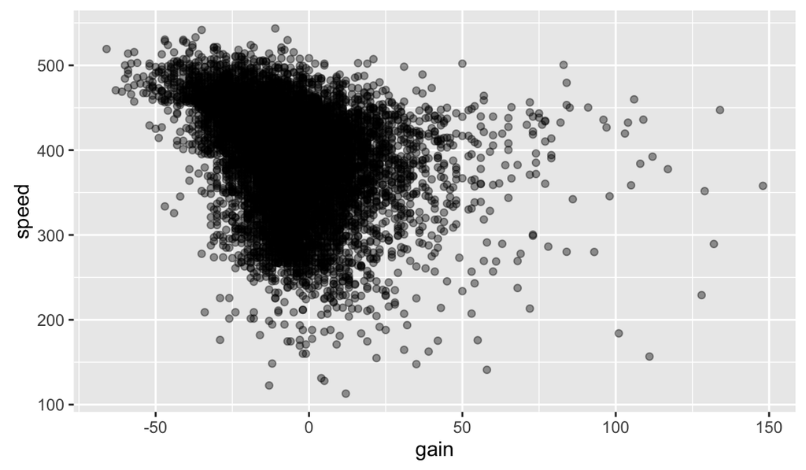

```r
library("ggplot2")
flights %>%
  mutate(gain = arr_delay - dep_delay,
    speed = (distance / air_time) * 60) %>%
  sample_n(10000) %>% # subsample 1e5 rows randomly
  ggplot(aes(x = gain, y = speed))+
  geom_point(alpha = 0.4)
```

## group_by

For the flights to Madison, let's compute the average delay per month.

instead of `aggregate`, `dplyr` has its own grouping function.  
Here, we `group_by` date. See the helpful reminder from `tbl_df` print method

```r
flights %>%
  filter(dest == "MSN") %>%
  group_by(month) %>%
  #Some values are missing, thus tell `mean` to remove them from the calculation.
  summarise(mean_dep_delay = mean(dep_delay, na.rm = TRUE))
```

```
## Source: local data frame [12 x 2]
##
##    month mean_dep_delay
##    (int)          (dbl)
## 1      1       18.07692
## 2      2       20.11111
## 3      3       41.87097
## 4      4       29.40741
## 5      5       21.54839
## 6      6       29.83333
## 7      7       11.13333
## 8      8       19.06667
## 9      9       15.97183
## 10    10       19.26190
## 11    11       15.96250
## 12    12       42.68831
```

## group_by (2)

Work per day, note the tibble info about the 365 groupings

```r
by_day <- flights %>%
  group_by(year, month, day)
by_day
```

```
## Source: local data frame [336,776 x 19]
## Groups: year, month, day [365]
##
##     year month   day dep_time sched_dep_time dep_delay arr_time
##    (int) (int) (int)    (int)          (int)     (dbl)    (int)
## 1   2013     1     1      517            515         2      830
## 2   2013     1     1      533            529         4      850
## 3   2013     1     1      542            540         2      923
## 4   2013     1     1      544            545        -1     1004
## 5   2013     1     1      554            600        -6      812
## 6   2013     1     1      554            558        -4      740
## 7   2013     1     1      555            600        -5      913
## 8   2013     1     1      557            600        -3      709
## 9   2013     1     1      557            600        -3      838
## 10  2013     1     1      558            600        -2      753
## ..   ...   ...   ...      ...            ...       ...      ...
## Variables not shown: sched_arr_time (int), arr_delay (dbl), carrier (chr),
##   flight (int), tailnum (chr), origin (chr), dest (chr), air_time (dbl),
##   distance (dbl), hour (dbl), minute (dbl), time_hour (time)
```

## summarise

Now we use `summarise` to compute (several) aggregate values within each group (per day). `summarise` returns one row per group.

```r
by_day %>%
  summarise(
    flights = n(), # dplyr specific function
    avg_delay = mean(dep_delay, na.rm = TRUE),
    n_planes = n_distinct(tailnum)) # dplyr specific function
```

```
## Source: local data frame [365 x 6]
## Groups: year, month [?]
##
##     year month   day flights avg_delay n_planes
##    (int) (int) (int)   (int)     (dbl)    (int)
## 1   2013     1     1     842 11.548926      649
## 2   2013     1     2     943 13.858824      712
## 3   2013     1     3     914 10.987832      689
## 4   2013     1     4     915  8.951595      689
## 5   2013     1     5     720  5.732218      578
## 6   2013     1     6     832  7.148014      640
## 7   2013     1     7     933  5.417204      682
## 8   2013     1     8     899  2.553073      667
## 9   2013     1     9     902  2.276477      666
## 10  2013     1    10     932  2.844995      689
## ..   ...   ...   ...     ...       ...      ...
```

## Exercice

- In average, how many flights does a single plane perform each day?
- plot the distribution, display the mean / median (`geom_vline()`)
- plot the average delay per day. Use `tidyr:unite` and `as.Date`
- which day should be avoided?

## Solution 1

```r
by_day %>%
  summarise(flights = n(),
            avg_delay = mean(dep_delay, na.rm = TRUE),
            n_planes = n_distinct(tailnum)) %>%
  mutate(avg_flights = flights / n_planes)
```

```
## Source: local data frame [365 x 7]
## Groups: year, month [12]
##
##     year month   day flights avg_delay n_planes avg_flights
##    (int) (int) (int)   (int)     (dbl)    (int)       (dbl)
## 1   2013     1     1     842 11.548926      649    1.297381
## 2   2013     1     2     943 13.858824      712    1.324438
## 3   2013     1     3     914 10.987832      689    1.326560
## 4   2013     1     4     915  8.951595      689    1.328012
## 5   2013     1     5     720  5.732218      578    1.245675
## 6   2013     1     6     832  7.148014      640    1.300000
## 7   2013     1     7     933  5.417204      682    1.368035
## 8   2013     1     8     899  2.553073      667    1.347826
## 9   2013     1     9     902  2.276477      666    1.354354
## 10  2013     1    10     932  2.844995      689    1.352685
## ..   ...   ...   ...     ...       ...      ...         ...
```

## Solution 2

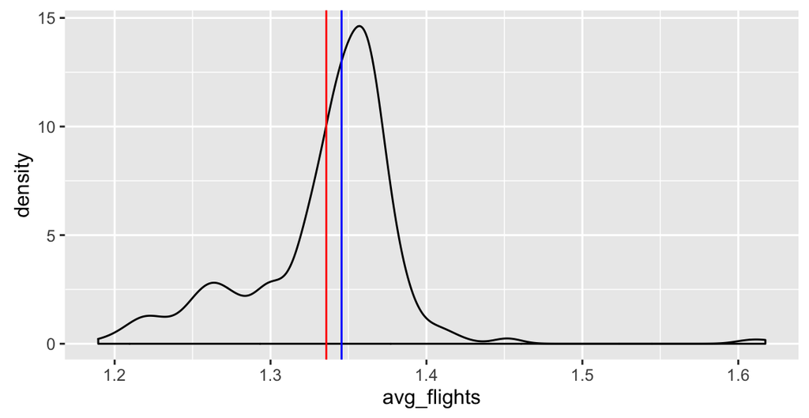

```r
by_day %>%
  summarise(flights = n(),
            avg_delay = mean(dep_delay, na.rm = TRUE),
            n_planes = n_distinct(tailnum)) %>%
  mutate(avg_flights = flights / n_planes) %>%
  ggplot()+
  geom_density(aes(x = avg_flights))+
  geom_vline(aes(xintercept = mean(avg_flights)), colour = "red")+
  geom_vline(aes(xintercept = median(avg_flights)), colour = "blue")
```

## Solution 3

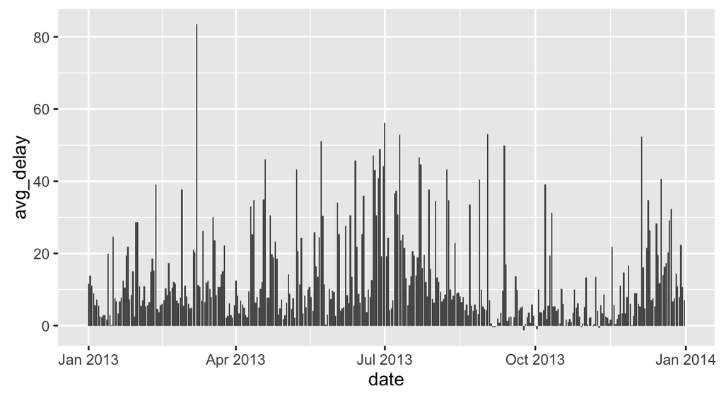

```r
library("tidyr")
by_day %>%
  summarise(avg_delay = mean(dep_delay, na.rm = TRUE)) %>%
  ungroup() %>%
  unite(date, -avg_delay, sep = "-") %>%
  mutate(date = as.Date(date)) %>%
  ggplot()+geom_bar(aes(x = date, y = avg_delay), stat = "identity")
```

## Solution 3

```r
by_day %>%
  summarise(avg_delay = mean(dep_delay, na.rm = TRUE)) %>%
  arrange(desc(avg_delay))
```

```
## Source: local data frame [365 x 4]
## Groups: year, month [12]
##
##     year month   day avg_delay
##    (int) (int) (int)     (dbl)
## 1   2013     1    31  28.65836
## 2   2013     1    30  28.62344
## 3   2013     1    16  24.61287
## 4   2013     1    25  21.89853
## 5   2013     1    13  19.87315
## 6   2013     1    24  19.46542
## 7   2013     1    28  15.13853
## 8   2013     1     2  13.85882
## 9   2013     1    22  12.49944
## 10  2013     1     1  11.54893
## ..   ...   ...   ...       ...
```

What's wrong?

## Solution 3.2

Mind that `arrange` uses grouping! (will change in version `0.4.5`)

```r
by_day %>%
  summarise(avg_delay = mean(dep_delay, na.rm = TRUE)) %>%
  ungroup %>%
  arrange(desc(avg_delay))
```

```
## Source: local data frame [365 x 4]
##
##     year month   day avg_delay
##    (int) (int) (int)     (dbl)
## 1   2013     3     8  83.53692
## 2   2013     7     1  56.23383
## 3   2013     9     2  53.02955
## 4   2013     7    10  52.86070
## 5   2013    12     5  52.32799
## 6   2013     5    23  51.14472
## 7   2013     9    12  49.95875
## 8   2013     6    28  48.82778
## 9   2013     6    24  47.15742
## 10  2013     7    22  46.66705
## ..   ...   ...   ...       ...
```

## Exercice

- Find the destinations with the highest average arrival delay?
- discard flights with missing arrival delays
- count the number of flights per destination
- discard results with less than 10 flights: mean will not be meaningful

## Solution

```r
flights %>%
  filter(!is.na(arr_delay)) %>%
  group_by(dest) %>%
  summarise(mean = mean(arr_delay),
            n = n()) %>%
  filter(n > 10) %>%
  arrange(desc(mean))
```

```
## Source: local data frame [101 x 3]
##
##     dest     mean     n
##    (chr)    (dbl) (int)
## 1    CAE 41.76415   106
## 2    TUL 33.65986   294
## 3    OKC 30.61905   315
## 4    JAC 28.09524    21
## 5    TYS 24.06920   578
## 6    MSN 20.19604   556
## 7    RIC 20.11125  2346
## 8    CAK 19.69834   842
## 9    DSM 19.00574   523
## 10   GRR 18.18956   728
## ..   ...      ...   ...
```

## Is there a spatial pattern for those delays?

First get the GPS coordinate of airports using the data frame `airports`

```r
airports
```

```
## Source: local data frame [1,396 x 7]
##
##      faa                           name      lat        lon   alt    tz
##    (chr)                          (chr)    (dbl)      (dbl) (int) (dbl)
## 1    04G              Lansdowne Airport 41.13047  -80.61958  1044    -5
## 2    06A  Moton Field Municipal Airport 32.46057  -85.68003   264    -5
## 3    06C            Schaumburg Regional 41.98934  -88.10124   801    -6
## 4    06N                Randall Airport 41.43191  -74.39156   523    -5
## 5    09J          Jekyll Island Airport 31.07447  -81.42778    11    -4
## 6    0A9 Elizabethton Municipal Airport 36.37122  -82.17342  1593    -4
## 7    0G6        Williams County Airport 41.46731  -84.50678   730    -5
## 8    0G7  Finger Lakes Regional Airport 42.88356  -76.78123   492    -5
## 9    0P2   Shoestring Aviation Airfield 39.79482  -76.64719  1000    -5
## 10   0S9          Jefferson County Intl 48.05381 -122.81064   108    -8
## ..   ...                            ...      ...        ...   ...   ...
## Variables not shown: dst (chr)
```

## join two data frames

```r
delays <- flights %>%
  filter(!is.na(arr_delay)) %>%
  group_by(dest) %>%
  summarise(mean = mean(arr_delay),
            n = n()) %>%
  filter(n > 10) %>%
  arrange(desc(mean)) %>%
  inner_join(airports, by = c("dest" = "faa")) # provide the equivalence since columns have a different name
```

We could have used **left_join** but 4 rows with a 3-letters acronym have no correspondance in the `airports` data frame.

**inner_join** narrows down the lines that are present in both data frames.

## join types

[figure not shown]

Of note: **anti_join** can select rows in which identifiers are **absent** in the second data frame.

## plot on a map

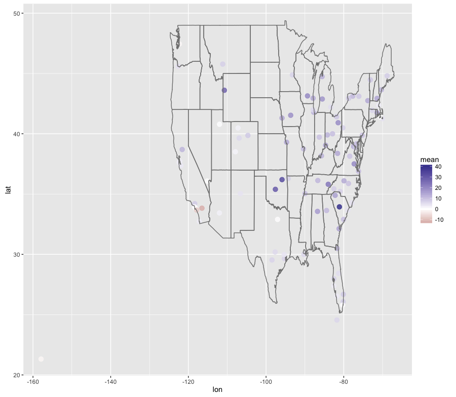

```r
library("ggplot2")
library("maps") # US map
ggplot(delays)+
  geom_point(aes(x = lon, y = lat, colour = mean), size = 3, alpha = 0.8)+
  scale_color_gradient2()+borders("state")
```

## plot on a map, with text

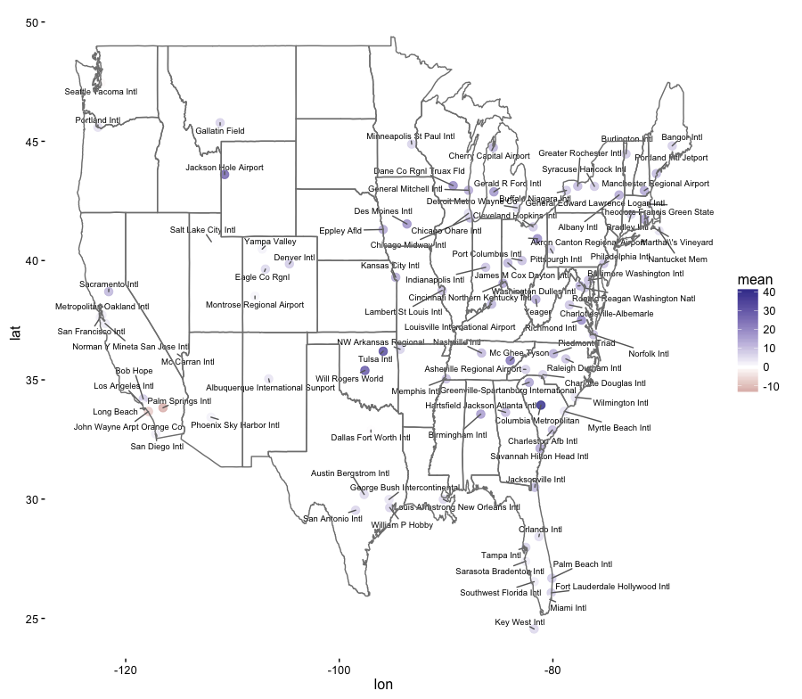

```r
library("ggrepel")
filter(delays, lon > -140) %>% # remove Honolulu
  ggplot()+geom_point(aes(x = lon, y = lat, colour = mean), size = 3, alpha = 0.8)+
  geom_text_repel(aes(x = lon, y = lat, label = name), size = 2.5)+
  scale_color_gradient2()+theme_classic()+borders("state")
```

## plot on a map, with conditional text

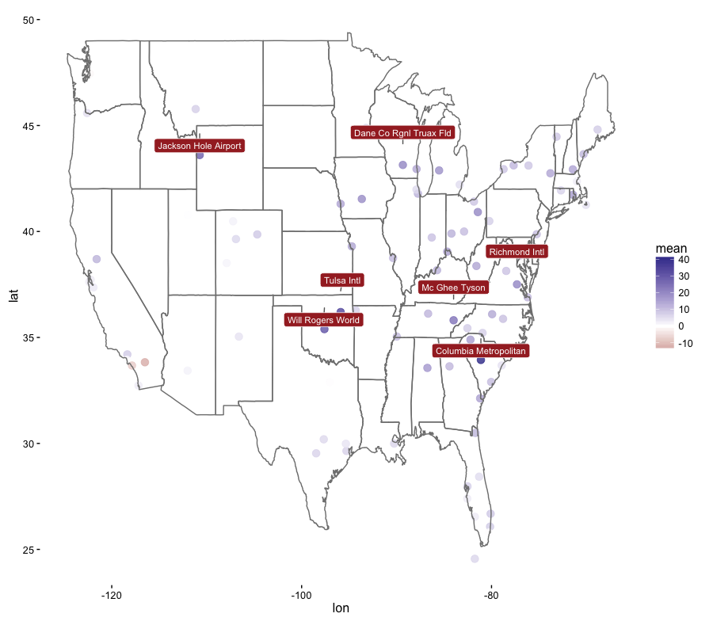

```r
filter(delays, lon > -140) %>% # remove Honolulu
  ggplot()+geom_point(aes(x = lon, y = lat, colour = mean),
                      size = 3, alpha = 0.8)+borders("state")+
  geom_label_repel(data = delays %>% filter(mean > 20),
            aes(x = lon, y = lat + 1, label = name), fill = "brown", colour = "white", size = 3)+
  scale_color_gradient2()+theme_classic()
```

## tally / count

`tally` is a shortcut to counting the number of items per group.

```r
flights %>%
  group_by(dest, month) %>%
  tally() %>% head(3) # could sum up with multiple tally calls
```

```
## Source: local data frame [3 x 3]
## Groups: dest [1]
##
##    dest month     n
##   (chr) (int) (int)
## 1   ABQ     4     9
## 2   ABQ     5    31
## 3   ABQ     6    30
```

`count` does the grouping for you

```r
flights %>%
  count(dest, month) %>% head(3)
```

```
## Source: local data frame [3 x 3]
## Groups: dest [1]
##
##    dest month     n
##   (chr) (int) (int)
## 1   ABQ     4     9
## 2   ABQ     5    31
## 3   ABQ     6    30
```

## That covers 80% of dplyr

- select
- filter
- arrange
- glimpse
- rename
- mutate
- group_by, ungroup
- summarise

## Other 20%

- assembly: `bind_rows`, `bind_cols`
- windows function, `min_rank`, `dense_rank`, `cumsum`
- column-wise operations: `mutate_each`, `transmute`, `summarise_each`
- join tables together: `right_join`, `full_join`
- filtering joins: `semi_join`, `anti_join`
- `do`: arbitrary code on each chunk
- different types of tabular data (databases, data.tables)

## bind_rows + purrr

How to read in and merge files in 2 lines

```r
library("purrr")
library("readxl")
files <- list.files(path = "./data/", pattern = "xlsx$", full.names = TRUE)
df <- lapply(files, read_excel) %>% bind_rows(.id = "file_number")
```

using `purrr`

```r
purr_df <- map_df(files, read_excel, .id = "file_number")
```

filenames are better

```r
library("stringr")
files %>%
  set_names(nm = str_match(basename(.), "([^.]+)\\.[[:alnum:]]+$")[, 2]) %>%
  map_df(read_excel, .id = "file_name") -> purr_name_df
```

## Appendix

## Coding style

`R` has a rather flexible and permissive syntax. However, being more strict tends to ease the debugging process.

See [Hadley's recommendations](http://adv-r.had.co.nz/Style.html)

```r
long_function_name <- function(a = "a long argument",
                               b = "another argument",
                               c = "another long argument") {
  # As usual code is indented by two spaces.
}
```

## Useful rstudio shortcuts

- Scripting (replace `Cmd` by `Ctrl` for PC)
  - `Cmd` + `-`: insert `<-`
  - `Cmd` + `Shift` + `M`: insert `%>%`
  - `Alt` + `↑` or `↓`: move line up / down
  - `Cmd` + `Alt` + `↑` or `↓`: copy line up / down
  - `Ctrl` + `Alt` + `↑` or `↓`: multi-line edition
- `# analysis step ####` for navigating
- Running
  - `Cmd` + `Enter`: run code
  - `Cmd` + `Shift` + `P`: re-run Previous code
  - `Cmd` + `Shift` + `K`: Knit document

## Rstudio addins

[Addins](https://rstudio.github.io/rstudioaddins/) are small integrated packages that solve small tasks.

[figure not shown]

Dean Attali created a [package](https://github.com/daattali/addinslist#readme) to explore and manage your addins.

Sometimes, cause crashes

## Recommended reading

- [R for data science](http://r4ds.had.co.nz/)

[figure not shown]

- [Advanced in R](http://adv-r.had.co.nz/) by Hadley
- About R weirdness
  - [R inferno](http://www.burns-stat.com/documents/books/the-r-inferno/) by Patrick Burns
  - [Rbitrary](https://ironholds.org/projects/rbitrary/) by Oliver Keyes

See why: - `<-` and not `=` - `::` and not `:::` - `library` and not `require` etc.

## Acknowledgments

- Hadley Wickham
- Steve Simpson
- Jenny Bryan
- Dean Attali
- David Robinson
- Eric Koncina